# Homework #6

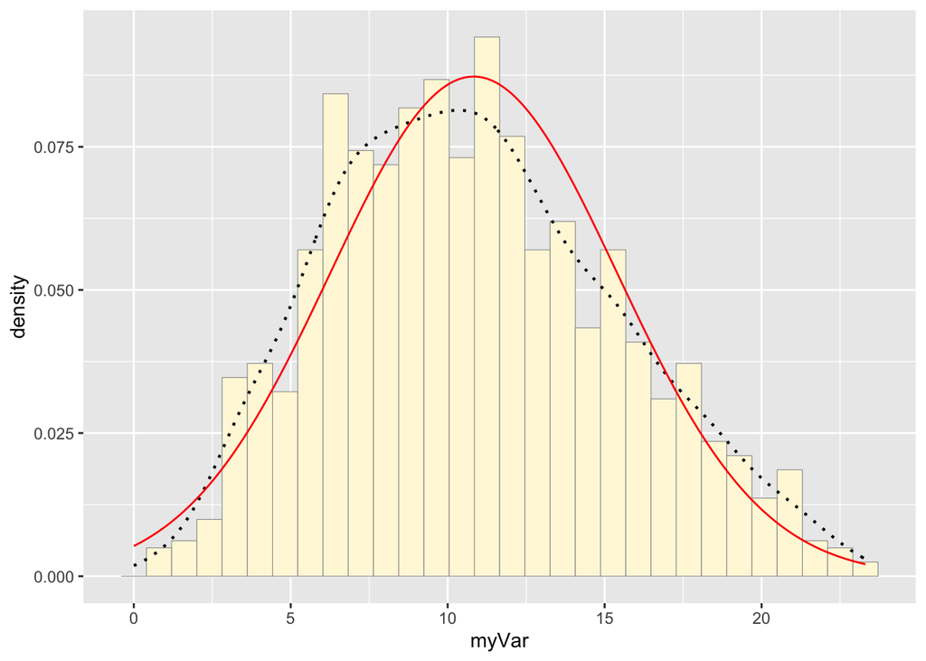

```r
# But the normal also is a pretty good fit.
meanML <- normPars$estimate["mean"]
sdML <- normPars$estimate["sd"]

xval <- seq(0,max(z$myVar),len=length(z$myVar))

stat <- stat_function(aes(x = xval, y = ..y..), fun = dnorm, colour="red", n = length(z$myVar), args = list(mean = meanML, sd = sdML))
p1 + stat
```

- Simulate a new data set. Using the best-fitting distribution, go back to the code and get the maximum likelihood parameters. Use those to simulate a new data set, with the same length as your original vector, and plot that in a histogram and add the probability density curve. Right below that, generate a fresh histogram plot of the original data, and also include the probability density

```r
# Using the best-fitting distribution, go back to the code and get the maximum likelihood parameters.

# Both the gamma and the normal distributions fit the data pretty well. I am going to explore both.
gammaPars <- fitdistr(z$myVar,"gamma")
# Getting Warning messages...
# 1: In densfun(x, parm[1], parm[2], ...) : NaNs produced
# 2: In densfun(x, parm[1], parm[2], ...) : NaNs produced
# 3: In densfun(x, parm[1], parm[2], ...) : NaNs produced
# 4: In densfun(x, parm[1], parm[2], ...) : NaNs produced
# Does this mean it is NOT a good fit?

# Extract the estimated parameters
# Pretty sure this is the same at the maximum likelihood parameters
shapeML <- gammaPars$estimate["shape"]
rateML <- gammaPars$estimate["rate"]
size_parameter <- gammaPars$estimate["size"]

print(gammaPars)
```

```
##      shape         rate
##   4.83401978   0.44639828
##  (0.20872994) (0.02031225)
```

```r
# This returns the same result as getting each separately, see below
#shape         rate
#4.83401978   0.44639828
#(0.20872994) (0.02031225)

str(gammaPars)
```

```
## List of 5
##  $ estimate: Named num [1:2] 4.834 0.446
##   ..- attr(*, "names")= chr [1:2] "shape" "rate"
##  $ sd      : Named num [1:2] 0.2087 0.0203
##   ..- attr(*, "names")= chr [1:2] "shape" "rate"
##  $ vcov    : num [1:2, 1:2] 0.043568 0.004023 0.004023 0.000413
##   ..- attr(*, "dimnames")=List of 2
##   .. ..$ : chr [1:2] "shape" "rate"
##   .. ..$ : chr [1:2] "shape" "rate"
##  $ loglik  : num -2952
##  $ n       : int 1004
##  - attr(*, "class")= chr "fitdistr"
```

```r
# gammaPars is  a list of 5 elements
# Not sure why I get two values for each, does each refer to shape and rate?
# List of 5
# $ estimate: Named num [1:2] 4.834 0.446
# ..- attr(*, "names")= chr [1:2] "shape" "rate"
# $ sd      : Named num [1:2] 0.2087 0.0203
# ..- attr(*, "names")= chr [1:2] "shape" "rate"
# $ vcov    : num [1:2, 1:2] 0.043568 0.004023 0.004023 0.000413
# ..- attr(*, "dimnames")=List of 2
# .. ..$ : chr [1:2] "shape" "rate"
# .. ..$ : chr [1:2] "shape" "rate"
# $ loglik  : num -2952
# $ n       : int 1004
# - attr(*, "class")= chr "fitdistr"

gammaPars$estimate["mean"] # get a named attribute
```

```
## <NA>
##   NA
```

```r
# NA
# this returns NA, so not sure it can work to generate a new data set
# mean = shape*scale...but not sure how to apply this here, or even if it should be applied
# Here is each parameter separately

shapeML
```

```
##   shape
## 4.83402
```

```r
# 4.83402
rateML
```

```
##      rate
## 0.4463983
```

```r
# 0.4463983
size_parameter
```

```
## <NA>
##   NA
```

```r
# NA
# is size the same as mean?

meanML <- gammaPars$estimate["mean"]
print (meanML)
```

```
## <NA>
##   NA
```

```r
#NA
sdML <- gammaPars$estimate["sd"]
print (sdML)
```

```
## <NA>
##   NA
```

```r
#NA
# from the structure call above...
# $ sd      : Named num [1:2] 0.2087 0.0203

# Use maximum likelihood parameters from my data set to simulate a new data set, with the same length as your original vector, and plot that in a histogram and add the probability density curve. Right below that, generate a fresh histogram plot of the original data, and also include the probability density

# I am going to use these parameters in the code that we used to generate the original practice data set

head(z$myVar)
```

```
## [1]  3.57  8.17 11.35 14.27 16.14  6.22
```

```r
# First I am going to take a look at my variable just for kicks
#[1]  3.57  8.17 11.35 14.27 16.14  6.22
str(z$myVar)
```

```
##  num [1:1004] 3.57 8.17 11.35 14.27 16.14 ...
```

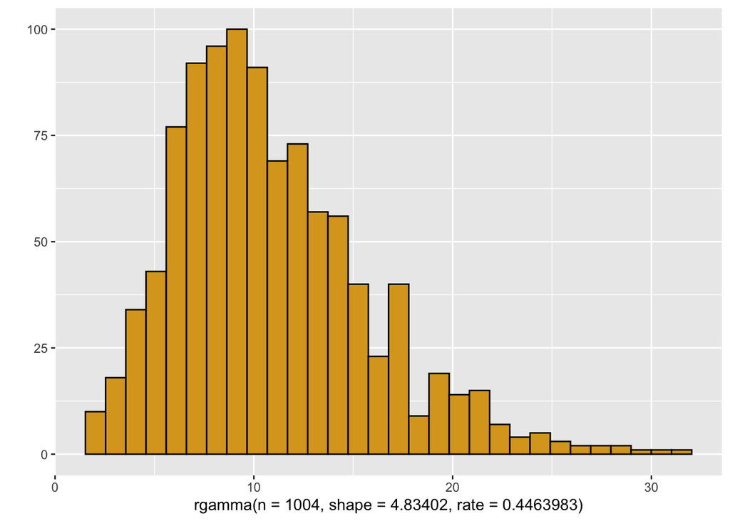

```r
#  num [1:1004] 3.57 8.17 11.35 14.27 16.14 ...
# Does this mean that I have 1004 numbers?

# We generated the randome data set different ways in class
# I am not sure which one is appropriate, so I will try a couple

qplot(rgamma(n=1004,shape=4.83402,rate=0.4463983),color=I("black"),fill=I("goldenrod"))
```

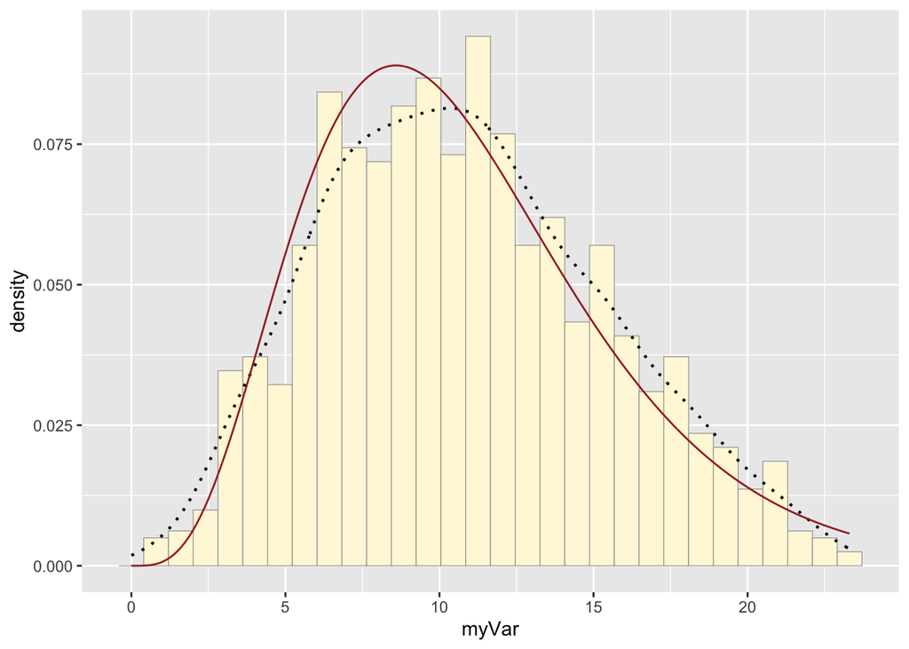

```r
# make a formal ggplot call, then can stack
# change transparency...caallled alpha

p1 + stat4
```

```r
normPars <- fitdistr(z$myVar,"normal")
print(normPars)
```

```
##       mean          sd
##   10.8289333    4.5714441
##  ( 0.1442735) ( 0.1020168)
```

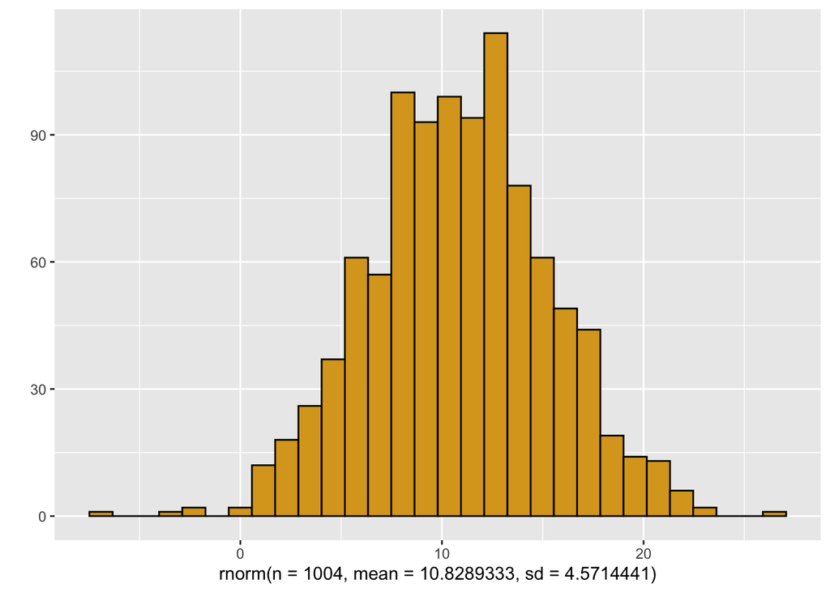

```r
qplot(rnorm(n=1004,mean=10.8289333,sd=4.5714441),color=I("black"),fill=I("goldenrod"))
```

```r
#  scale = 1/rate
# if study is small, can increase n
# Here one way that we generated a data set
# I substituted values returned with the calls above
# $ n       : int 1004
# shapeML, 4.83402
# I am not sure what to do with scale
# I will leave it at 100 for now

# nbiRan <- rnbinom(n=1004,size=.5,mu=4.83402 )
# qplot(nbiRan,color=I("black"),fill=I("goldenrod"))
# nbiRan <- rnbinom(n=1004,size=5,mu=4.83402 )
# qplot(nbiRan,color=I("black"),fill=I("goldenrod"))
# nbiRan <- rnbinom(n=1004,size=50,mu=4.83402 )
# qplot(nbiRan,color=I("black"),fill=I("goldenrod"))
# nbiRan <- rnbinom(n=1004,size=500,mu=4.83402 )
# qplot(nbiRan,color=I("black"),fill=I("goldenrod"))
# nbiRan <- rnbinom(n=1004,size=5000,mu=4.83402 )
# qplot(nbiRan,color=I("black"),fill=I("goldenrod"))
# I think mu=mean, n was returned in the results above, size returns NA

#myVec <- dpois(x=hits,lambda=1)
#qplot(x=hits,y=myVec,geom="col",color=I("black"),fill=I("goldenrod"))
# here is the code for the "d" function which generates probability density
# It seems like I should chage some of the inputs, but not sure how to do this
```

- How do the two histogram profiles compare? Do you think the model is doing a good job of simulating realistic data that match your original measurements? Why or why not?

Pretty close Not sure about the upper limit outlier I am going to try the same with the normal

I am unclear how I created an alternative data set, so I am struggling to answer this question.

- If you have entered a large data frame with many columns, try running all of the code on a different variable to see how the simulation performs.

The dataframe enetered only has two columns, so this does not apply.